# Quantile Regression

Vincenzo Coia

```r
suppressPackageStartupMessages(library(tidyverse))
suppressPackageStartupMessages(library(Lahman))
```

It’s common to “default” to using the mean to make decisions. But, the mean is not always appropriate (I wrote a [blog post](https://vincenzocoia.github.io/20180218-mean/) about this):

- Sometimes it makes sense to relate the outcome to a coin toss.
  - For example, find an amount for which next month’s expenditures will either exceed or be under with a 50% chance.
- Sometimes a conservative/liberal estimate is wanted.
  - For example, a bus company wants conservative estimates so that *most* busses fall within the estimated travel time.

In these cases, we care about *quantiles*, not the mean. Estimating them is called **quantile regression** (as opposed to **mean regression**).

Recall what quantiles are: the $\tau$-quantile (for $\tau$ between 0 and 1) is the number that will be exceeded by the outcome with a $(1-\tau)$ chance. In other words, there is a probability of $\tau$ that the outcome will be *below* the $\tau$-quantile.

$\tau$ is referred to as the *quantile level*, or sometimes the *quantile index*.

For example, a bus company might want to predict the 0.8-quantile of transit time – 80% of busses will get to their destination within that time.

## What is the mean, anyway?

Imagine trying to predict your total expenses for the next two years. You have monthly expenses listed for the past 12 months. What’s one simple way of making your prediction? Calculate the average expense from the past 12 months, and multiply that by 24.

In general, a mean (or expected value) can be interpreted as the *long-run average*. However, the mean tends to be interpreted as a *measure of central tendency*, which has a more nebulous interpretation as a “typical” outcome, or an outcome for which most of the data will be “nearest”.

## Linear Quantile Regression

The idea here is to model
$$Q(\tau)=\beta_0(\tau) + \beta_1(\tau) X_1 + \cdots + \beta_p(\tau) X_p,$$
where $Q(\tau)$ is the $\tau$-quantile. In other words, **each quantile level gets its own line**, and are each fit independently of each other.

Here are the 0.25-, 0.5-, and 0.75-quantile regression lines for the baseball data:

```
## Smoothing formula not specified. Using: y ~ x
```

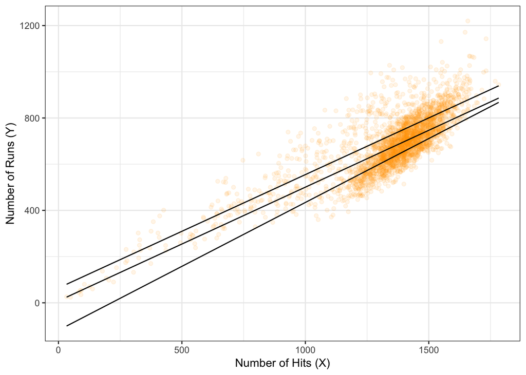

```r
dat <- Teams %>% tbl_df %>%
  select(runs=R, hits=H)
ggplot(dat, aes(hits, runs)) +
    geom_point(alpha=0.1, colour="orange") +
    geom_quantile(colour="black") +
    theme_bw() +
    labs(x="Number of Hits (X)",
         y="Number of Runs (Y)")
```

I did this easily with `ggplot2`, just by adding a layer `geom_quantile` to my scatterplot, specifying the quantile levels with the `quantiles=` argument. We could also use the function `rq` in the `quantreg` package in R:

```r
(fit_rq <- rq(runs ~ hits, data=dat, tau=c(0.25, 0.5, 0.75)))
```

```
## Call:
## rq(formula = runs ~ hits, tau = c(0.25, 0.5, 0.75), data = dat)
##
## Coefficients:
##                tau= 0.25 tau= 0.50  tau= 0.75
## (Intercept) -118.8297872 8.2101818 64.0347349
## hits           0.5531915 0.4923636  0.4908592
##
## Degrees of freedom: 2835 total; 2833 residual
```

If we were to again focus on the two teams (one with 1000 hits, and one with 1500 hits), we have (by evaluating the above three lines):

```r
predict(fit_rq, newdata=data.frame(hits=c(1000, 1500)))
```

```
##   tau= 0.25 tau= 0.50 tau= 0.75
## 1  434.3617  500.5738  554.8940
## 2  710.9574  746.7556  800.3236
```

So, we could say that the team with 1000 hits:

- is estimated to have a 50% chance to have between 434 and 555 runs;
- has a 25% chance of achieving over 555 runs;
- has a 25% chance of getting less than 434 runs;
- would typically get 501 runs (median);

amongst other things.

## Exercise

- Get a 95% prediction interval using linear quantile regression, with Y=`R` (number of runs), X=`H` (number of hits), when X=1500.
- What about a 95% PI using kNN, going back to the earlier example we did?

## Problem: Crossing quantiles

Because each quantile is allowed to have its own line, some of these lines might cross, giving an **invalid result**. Here is an example with the `iris` data set, fitting the 0.2- and 0.3-quantiles:

```
## Smoothing formula not specified. Using: y ~ x
## Smoothing formula not specified. Using: y ~ x
```

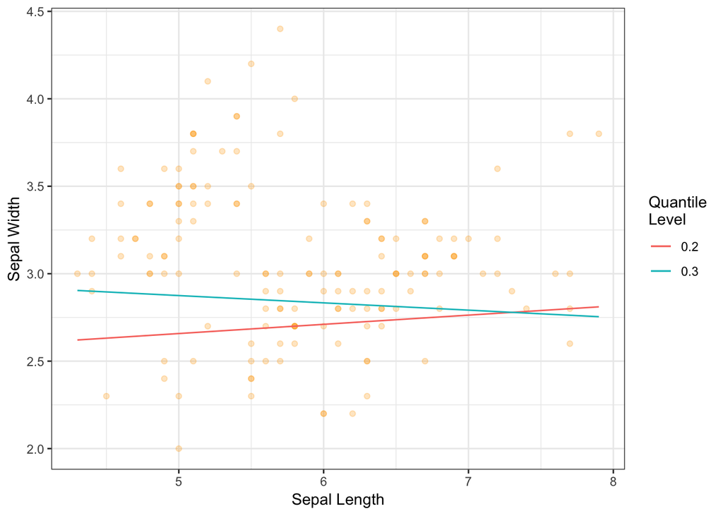

```r
ggplot(iris, aes(Sepal.Length, Sepal.Width)) +
    geom_point(alpha=0.25, colour="orange") +
    geom_quantile(aes(colour="0.2"), quantiles=0.2) +
    geom_quantile(aes(colour="0.3"), quantiles=0.3) +
    scale_colour_discrete("Quantile\nLevel") +
    theme_bw() +
    labs(x="Sepal Length",
         y="Sepal Width")
```

```r
fit_iris <- rq(Sepal.Width ~ Sepal.Length, data=iris, tau=2:3/10)
b <- coef(fit_iris)
at8 <- round(predict(fit_iris, newdata=data.frame(Sepal.Length=8)), 2)
```

Quantile estimates of Sepal Width for plants with Sepal Length less than `7.3` are valid, but otherwise, are not. For example, for plants with a Sepal Length of 8, this model predicts 30% of such plants to have a Sepal Width of less than `2.75`, but only 20% of such plants should have Sepal Width less than `2.82`. This is an illogical statement.

There have been several “adjustments” proposed to ensure that this doesn’t happen (see below), but ultimately, this suggests an inadequacy in the model assumptions. Luckily, this usually only happens at extreme values of the predictor space, and/or for large quantile levels, so is usually not a problem.

- Bondell HD, Reich BJ, Wang H. Noncrossing quantile regression curve estimation. Biometrika. 2010;97(4):825-838.
- Dette H, Volgushev S. Non-crossing non-parametric estimates of quantile curves. J R Stat Soc Ser B Stat Methodol. 2008;70(3):609-627.
- Tokdar ST, Kadane JB. Simultaneous linear quantile regression: a semiparametric Bayesian approach. Bayesian Anal. 2011;6(4):1-22.

## Problem: Upper quantiles

Estimates of higher quantiles usually become worse for large/small values of $\tau$. This is especially true when data are heavy-tailed.

Here is a histogram of 100 observations generated from a Student’s *t*(1) distribution (it’s heavy-tailed):

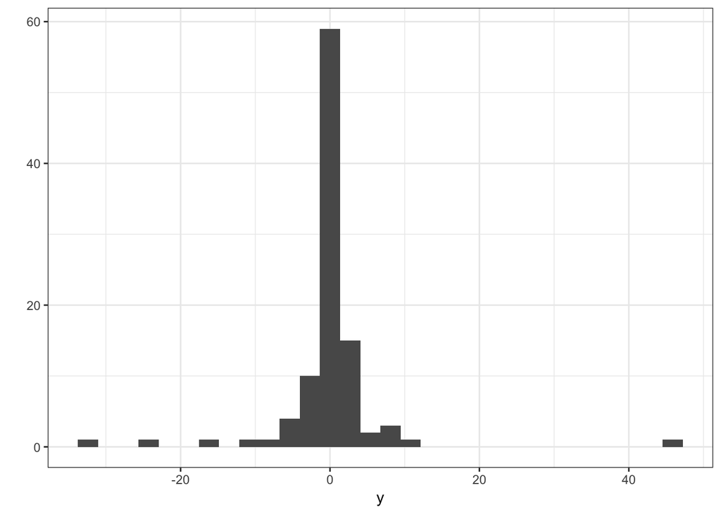

```r
set.seed(4)
y <- rt(100, df=1)
qplot(y) + theme_bw()
```

Here are estimates of high and low quantiles, compared to the actual. You can see the discrepency grows quickly. **Extreme-low quantiles are too high**, whereas **extreme-high quantiles are too low**.

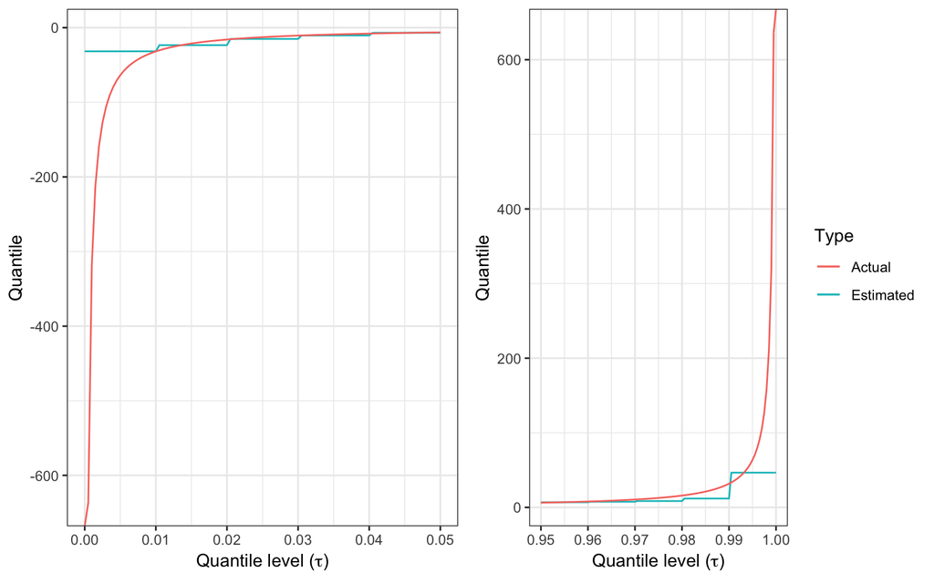

As a rule of thumb, it’s best to stay below $\tau=0.95$ or above $\tau=0.05$. If you really want estimates of these extreme quantiles, you’ll need to turn to **Extreme Value Theory** to make an assumption on the tail of the distribution of the data. One common approach is to fit a generalized Pareto distribution to the upper portion of the data, after which you can extract high quantiles.

## Evaluating Model Goodness

The question here is: if we have two or more models that predicts the $\tau$-quantile, which model is best? We’ll need some way to score different models to do things such as:

- Choose which predictors to include in a model;
- Choose optimal hyperparameters;
- Estimate parameters in a quantile regression model.

****NOTE****: **Mean Squared Error is not appropriate here!!** This is very important to remember.

The reason is technical – the MSE is not a *proper scoring rule* for quantiles. In other words, the MSE does not elicit an honest prediction.

If we’re predicting the **median**, then the *mean absolute error* works. This is like the MSE, but instead of *squaring* the errors, we take the *absolute value*.

In general, a “correct” scoring rule for the $\tau$-quantile is as follows:
$$S = \sum_{i=1}^{n} \rho_{\tau}(Y_i - \hat{Q}_i(\tau)),$$
where $Y_i$ for $i=1,\ldots,n$ is the response data, $\hat{Q}_i(\tau)$ are the $\tau$-quantile estimates, and $\rho_{\tau}$ is the **check function** (also known as the *absolute asymmetric deviation function* or *tick function*), given by
$$\rho_{\tau}(s) = (\tau - I(s<0))s$$
for real $s$. This scoring rule is **negatively oriented**, meaning the lower the score, the better. It cannot be below 0.

Here is a plot of various check functions. Notice that, when $\tau=0.5$ (corresponding to the median), this is proportional to the absolute value:

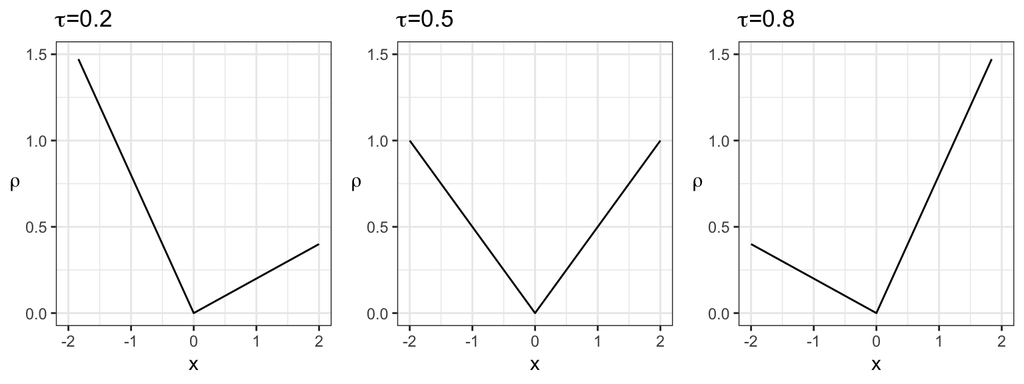

```r
base <- ggplot(data.frame(x=c(-2,2)), aes(x)) +
    theme_bw() +
    labs(y=expression(rho)) +
    theme(axis.title.y=element_text(angle=0, vjust=0.5)) +
    ylim(c(0, 1.5))
rho <- function(tau) function(x) (tau - (x<0))*x
cowplot::plot_grid(
    base + stat_function(fun=rho(0.2)) +
        ggtitle(expression(paste(tau, "=0.2"))),
    base + stat_function(fun=rho(0.5)) +
        ggtitle(expression(paste(tau, "=0.5"))),
    base + stat_function(fun=rho(0.8)) +
        ggtitle(expression(paste(tau, "=0.8"))),
    ncol=3
)
```

For quantile regression **estimation**, we minimize the sum of scores instead of the sum of squared residuals, as in the usual (mean) linear regression.